# SE 412 Project 1 - Market Basket Analysis

Khusbu Bhushal

2025-11-30

# INTRODUCTION

This project uses market basket analysis to explore frequent itemsets and association rules.

# LOAD PACKAGES

```r
library(arules)
library(arulesViz)
library(tidyverse)
library(readxl)
library(plyr)
library(knitr)
```

# LOAD DATA

```r
Itemslist <- read.csv2("Assignment-1_Data.csv", check.names = FALSE)
Itemslist <- Itemslist[complete.cases(Itemslist), ]
head(Itemslist)
```

```
##   BillNo                            Itemname Quantity             Date Price
## 1 536365  WHITE HANGING HEART T-LIGHT HOLDER        6 01.12.2010 08:26  2.55
## 2 536365                 WHITE METAL LANTERN        6 01.12.2010 08:26  3.39
## 3 536365      CREAM CUPID HEARTS COAT HANGER        8 01.12.2010 08:26  2.75
## 4 536365 KNITTED UNION FLAG HOT WATER BOTTLE        6 01.12.2010 08:26  3.39
## 5 536365      RED WOOLLY HOTTIE WHITE HEART.        6 01.12.2010 08:26  3.39
## 6 536365        SET 7 BABUSHKA NESTING BOXES        2 01.12.2010 08:26  7.65
##   CustomerID        Country
## 1      17850 United Kingdom
## 2      17850 United Kingdom
## 3      17850 United Kingdom
## 4      17850 United Kingdom
## 5      17850 United Kingdom
## 6      17850 United Kingdom
```

# PREPROCESSING

```r
# Group items into full transactions
transactionData <- ddply(Itemslist, c("BillNo","Country"),
                         function(df1) paste(df1$Itemname, collapse=","))

colnames(transactionData) <- c("BillNo", "Country", "items")

# Create France & Other datasets
franceData <- subset(transactionData, Country == "France")
otherData  <- subset(transactionData, Country != "France")

# Remove Country column
franceData$Country <- NULL
otherData$Country  <- NULL

colnames(franceData) <- c("BillNo", "items")
colnames(otherData)  <- c("BillNo", "items")

# Prepare item-only data frames for Apriori
transactionData_apriori <- data.frame(items = transactionData$items)
france_apriori          <- data.frame(items = franceData$items)
other_apriori           <- data.frame(items = otherData$items)

# Save CSVs
write.csv(transactionData_apriori, "transactions_basket.csv", quote=FALSE, row.names=FALSE)
write.csv(france_apriori,          "france_basket.csv",       quote=FALSE, row.names=FALSE)
write.csv(other_apriori,           "other_basket.csv",        quote=FALSE, row.names=FALSE)

# Load into transaction objects
trans_all   <- read.transactions("transactions_basket.csv", format="basket", sep=",")
```

[output not shown]

[output cut: 5409 more lines]

[output not shown]

```r
trans_fra   <- read.transactions("france_basket.csv",       format="basket", sep=",")
```

[output not shown]

[output cut: 79 more lines]

[output not shown]

```r
trans_other <- read.transactions("other_basket.csv",        format="basket", sep=",")
```

[output not shown]

[output cut: 5271 more lines]

[output not shown]

```r
summary(trans_all)
```

```
## transactions as itemMatrix in sparse format with
##  18164 rows (elements/itemsets/transactions) and
##  7699 columns (items) and a density of 0.002293202
##
## most frequent items:
## WHITE HANGING HEART T-LIGHT HOLDER           REGENCY CAKESTAND 3 TIER
##                               1717                               1468
##            JUMBO BAG RED RETROSPOT                      PARTY BUNTING
##                               1394                               1244
##      ASSORTED COLOUR BIRD ORNAMENT                            (Other)
##                               1226                             313643
##
## element (itemset/transaction) length distribution:
## sizes
##    1    2    3    4    5    6    7    8    9   10   11   12   13   14   15   16
## 1541  857  742  741  742  693  642  632  631  565  598  517  494  519  530  509
##   17   18   19   20   21   22   23   24   25   26   27   28   29   30   31   32
##  457  429  467  406  385  307  303  267  233  246  226  210  212  208  164  153
##   33   34   35   36   37   38   39   40   41   42   43   44   45   46   47   48
##  135  139  131  106  110   87  108   91   87   86   84   62   59   67   59   58
##   49   50   51   52   53   54   55   56   57   58   59   60   61   62   63   64
##   57   47   61   39   39   47   41   34   27   37   29   26   27   16   24   25
##   65   66   67   68   69   70   71   72   73   74   75   76   77   78   79   80
##   20   27   24   21   14   20   19   13   16   15   11   15   12    6    8   14
##   81   82   83   84   85   86   87   88   89   90   91   92   93   94   95   96
##   13   10    8    8   11   10   13    8    6    5    5   11    5    4    4    3
##   97   98   99  100  101  102  103  104  105  106  107  108  109  110  111  112
##    5    5    2    4    1    4    4    2    2    2    6    3    4    3    2    1
##  113  114  116  117  118  120  121  122  123  125  126  127  131  132  133  134
##    3    1    3    3    3    1    2    2    1    3    2    2    1    1    2    1
##  140  141  142  143  145  146  147  150  154  157  168  171  177  178  180  202
##    1    2    2    1    1    2    1    1    3    2    2    2    1    1    1    1
##  204  228  236  249  250  285  320  400  419
##    1    1    1    1    1    1    1    1    1
##
##    Min. 1st Qu.  Median    Mean 3rd Qu.    Max.
##    1.00    5.00   13.00   17.66   23.00  419.00
##
## includes extended item information - examples:
##                       labels
## 1                   1 HANGER
## 2     10 COLOUR SPACEBOY PEN
## 3 12 COLOURED PARTY BALLOONS
```

```r
summary(trans_fra)
```

```
## transactions as itemMatrix in sparse format with
##  390 rows (elements/itemsets/transactions) and
##  1523 columns (items) and a density of 0.01184067
##
## most frequent items:
##                            POSTAGE                 RABBIT NIGHT LIGHT
##                                249                                 67
##      RED TOADSTOOL LED NIGHT LIGHT      PLASTERS IN TIN CIRCUS PARADE
##                                 61                                 55
## ROUND SNACK BOXES SET OF4 WOODLAND                            (Other)
##                                 54                               6547
##
## element (itemset/transaction) length distribution:
## sizes
##   1   2   3   4   5   6   7   8   9  10  11  12  13  14  15  16  17  18  19  20
##  21  14   7  10  16  10  16  14   6  25  15  12  15  15   7  12  14  12  13  12
##  21  22  23  24  25  26  27  28  29  30  31  32  33  34  35  36  38  39  40  41
##  10  10   8  10   4   4   5   3   5   6   6   6   4   1   5   2   3   4   3   2
##  42  43  45  46  47  49  52  57  58  61  62  64  66  67  68  87 204
##   1   1   1   1   3   3   1   1   1   2   1   1   1   2   1   1   1
##
##    Min. 1st Qu.  Median    Mean 3rd Qu.    Max.
##    1.00    8.00   14.00   18.03   23.00  204.00
##
## includes extended item information - examples:
##                       labels
## 1     10 COLOUR SPACEBOY PEN
## 2 12 COLOURED PARTY BALLOONS
## 3  12 EGG HOUSE PAINTED WOOD
```

```r
summary(trans_other)
```

```
## transactions as itemMatrix in sparse format with
##  17775 rows (elements/itemsets/transactions) and
##  7613 columns (items) and a density of 0.002317895
##
## most frequent items:
## WHITE HANGING HEART T-LIGHT HOLDER           REGENCY CAKESTAND 3 TIER
##                               1716                               1422
##            JUMBO BAG RED RETROSPOT                      PARTY BUNTING
##                               1364                               1224
##      ASSORTED COLOUR BIRD ORNAMENT                            (Other)
##                               1212                             306722
##
## element (itemset/transaction) length distribution:
## sizes
##    1    2    3    4    5    6    7    8    9   10   11   12   13   14   15   16
## 1521  843  735  731  726  683  626  618  625  540  583  505  479  504  523  497
##   17   18   19   20   21   22   23   24   25   26   27   28   29   30   31   32
##  443  417  454  394  375  297  295  257  229  242  221  207  207  202  158  147
##   33   34   35   36   37   38   39   40   41   42   43   44   45   46   47   48
##  131  138  126  104  110   84  104   88   85   85   83   62   58   66   56   58
##   49   50   51   52   53   54   55   56   57   58   59   60   61   62   63   64
##   54   47   61   38   39   47   41   34   26   36   29   26   25   15   24   24
##   65   66   67   68   69   70   71   72   73   74   75   76   77   78   79   80
##   20   26   22   20   14   20   19   13   16   15   11   15   12    6    8   14
##   81   82   83   84   85   86   87   88   89   90   91   92   93   94   95   96
##   13   10    8    8   11   10   12    8    6    5    5   11    5    4    4    3
##   97   98   99  100  101  102  103  104  105  106  107  108  109  110  111  112
##    5    5    2    4    1    4    4    2    2    2    6    3    4    3    2    1
##  113  114  116  117  118  120  121  122  123  125  126  127  131  132  133  134
##    3    1    3    3    3    1    2    2    1    3    2    2    1    1    2    1
##  140  141  142  143  145  146  147  150  154  157  168  171  177  178  180  202
##    1    2    2    1    1    2    1    1    3    2    2    2    1    1    1    1
##  228  236  249  250  285  320  400  419
##    1    1    1    1    1    1    1    1
##
##    Min. 1st Qu.  Median    Mean 3rd Qu.    Max.
##    1.00    5.00   13.00   17.65   23.00  419.00
##
## includes extended item information - examples:
##                       labels
## 1                   1 HANGER
## 2     10 COLOUR SPACEBOY PEN
## 3 12 COLOURED PARTY BALLOONS
```

##Everthing above in one dataframe is a tiny 3 row output that shows the printed example of item labels insidet the transaction object ##its purpose is to show a preview of item names so so you know what type of items are inside the transactions ##The bigger R Console data frame like output is a transaction length distribution that says: ## 1521 transactions contain 1 item , 843 transactions contain 2 items , 735 transactions contain 3 items , 419 items is the longest basket in the dataset (very large transaction)

# RQ1: What frequent itemsets and rules appear in the FULL dataset?

## RUN APRIORI FOR FULL DATASET

```r
rules_all <- apriori(trans_all,
                     parameter = list(supp = 0.01, conf = 0.5))
```

```
## Apriori
##
## Parameter specification:
##  confidence minval smax arem  aval originalSupport maxtime support minlen
##         0.5    0.1    1 none FALSE            TRUE       5    0.01      1
##  maxlen target  ext
##      10  rules TRUE
##
## Algorithmic control:
##  filter tree heap memopt load sort verbose
##     0.1 TRUE TRUE  FALSE TRUE    2    TRUE
##
## Absolute minimum support count: 181
##
## set item appearances ...[0 item(s)] done [0.00s].
## set transactions ...[7699 item(s), 18164 transaction(s)] done [0.11s].
## sorting and recoding items ... [500 item(s)] done [0.01s].
## creating transaction tree ... done [0.01s].
## checking subsets of size 1 2 3 4 done [0.01s].
## writing ... [159 rule(s)] done [0.00s].
## creating S4 object  ... done [0.01s].
```

```r
summary(rules_all)
```

```
## set of 159 rules
##
## rule length distribution (lhs + rhs):sizes
##  2  3  4
## 81 74  4
##
##    Min. 1st Qu.  Median    Mean 3rd Qu.    Max.
##   2.000   2.000   2.000   2.516   3.000   4.000
##
## summary of quality measures:
##     support          confidence        coverage            lift
##  Min.   :0.01002   Min.   :0.5010   Min.   :0.01068   Min.   : 6.40
##  1st Qu.:0.01082   1st Qu.:0.5568   1st Qu.:0.01715   1st Qu.:11.37
##  Median :0.01178   Median :0.6006   Median :0.01993   Median :13.70
##  Mean   :0.01331   Mean   :0.6470   Mean   :0.02121   Mean   :21.50
##  3rd Qu.:0.01409   3rd Qu.:0.7030   3rd Qu.:0.02310   3rd Qu.:22.74
##  Max.   :0.02604   Max.   :1.0000   Max.   :0.04432   Max.   :86.50
##      count
##  Min.   :182.0
##  1st Qu.:196.5
##  Median :214.0
##  Mean   :241.7
##  3rd Qu.:256.0
##  Max.   :473.0
##
## mining info:
##       data ntransactions support confidence
##  trans_all         18164    0.01        0.5
##                                                                  call
##  apriori(data = trans_all, parameter = list(supp = 0.01, conf = 0.5))
```

```r
inspect(head(rules_all, 10))
```

```
##      lhs                                 rhs                                support confidence   coverage     lift count
## [1]  {SET 3 RETROSPOT TEA}            => {SUGAR}                         0.01156133  1.0000000 0.01156133 86.49524   210
## [2]  {SUGAR}                          => {SET 3 RETROSPOT TEA}           0.01156133  1.0000000 0.01156133 86.49524   210
## [3]  {SET 3 RETROSPOT TEA}            => {COFFEE}                        0.01156133  1.0000000 0.01156133 65.57401   210
## [4]  {COFFEE}                         => {SET 3 RETROSPOT TEA}           0.01156133  0.7581227 0.01524994 65.57401   210
## [5]  {SUGAR}                          => {COFFEE}                        0.01156133  1.0000000 0.01156133 65.57401   210
## [6]  {COFFEE}                         => {SUGAR}                         0.01156133  0.7581227 0.01524994 65.57401   210
## [7]  {REGENCY TEA PLATE GREEN}        => {REGENCY TEA PLATE ROSES}       0.01029509  0.8385650 0.01227703 56.20552   187
## [8]  {REGENCY TEA PLATE ROSES}        => {REGENCY TEA PLATE GREEN}       0.01029509  0.6900369 0.01491962 56.20552   187
## [9]  {ALARM CLOCK BAKELIKE CHOCOLATE} => {ALARM CLOCK BAKELIKE RED}      0.01018498  0.7142857 0.01425897 17.79737   185
## [10] {SET/6 RED SPOTTY PAPER CUPS}    => {SET/6 RED SPOTTY PAPER PLATES} 0.01139617  0.8181818 0.01392865 51.78207   207
```

### The Apriori algorithm discovered several very strong association rules in the full dataset. For example, {SET 3 RETROSPOT TEA} ⇒ {SUGAR} has 100% confidence and lift = 86.49, indicating that customers who purchase this tea set are extremely likely to also purchase sugar. The reversed rule {SUGAR} ⇒ {SET 3 RETROSPOT TEA} also holds with the same confidence and lift, meaning these items almost always appear together. These high-lift rules show strong product affinities that could inform product placement and bundling strategies.

### IT also shows set of 159 rules

###Confidence ###→ Many rules are strong because confidence is 0.50 to 1.00 ###(50%–100% probability of RHS given LHS)

###Lift ###→ Lift values range from 6 to 86, meaning: ###lift > 1 = items occur together more than random chance ###lift > 10 = very strong association ###lift ~ 80 = extremely strong association

## ITEM FREQUENCY PLOT

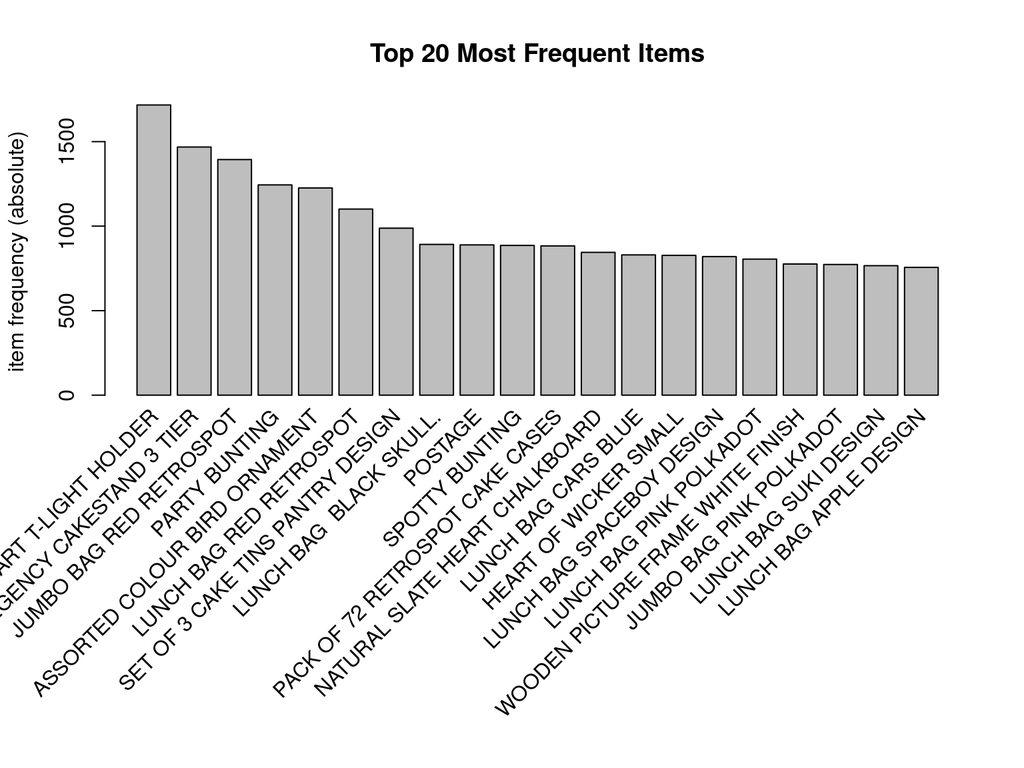

```r
itemFrequencyPlot(trans_all,
                  topN = 20,
                  type = "absolute",
                  main = "Top 20 Most Frequent Items")
```

## SCATTER PLOT FOR ALL RULES

```
## To reduce overplotting, jitter is added! Use jitter = 0 to prevent jitter.
```

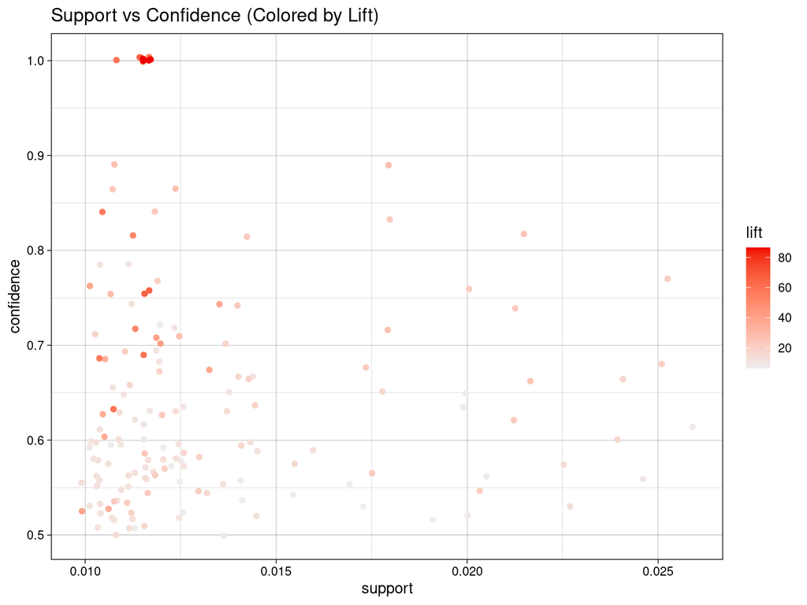

```r
plot(rules_all,
     measure = c("support","confidence"),
     shading = "lift",
     main = "Support vs Confidence (Colored by Lift)")
```

## GRAPH OF TOP 20 STRONGEST RULES

[output not shown]

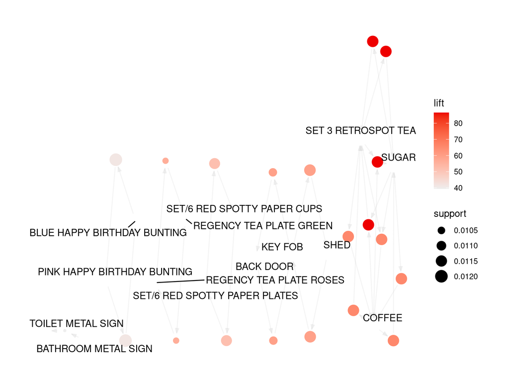

```r
top20 <- head(sort(rules_all, by="lift"), 20)
plot(top20, method="graph", control=list(type="items"),
     main="Top 20 Strongest Association Rules")
```

# RQ2: How do rules differ for France vs Other Regions?

## APRIORI FOR FRANCE

```r
rules_fra <- apriori(trans_fra,
                     parameter = list(supp = 0.01, conf = 0.5))
```

```
## Apriori
##
## Parameter specification:
##  confidence minval smax arem  aval originalSupport maxtime support minlen
##         0.5    0.1    1 none FALSE            TRUE       5    0.01      1
##  maxlen target  ext
##      10  rules TRUE
##
## Algorithmic control:
##  filter tree heap memopt load sort verbose
##     0.1 TRUE TRUE  FALSE TRUE    2    TRUE
##
## Absolute minimum support count: 3
##
## set item appearances ...[0 item(s)] done [0.00s].
## set transactions ...[1523 item(s), 390 transaction(s)] done [0.00s].
## sorting and recoding items ... [471 item(s)] done [0.00s].
## creating transaction tree ... done [0.00s].
## checking subsets of size 1 2 3 4 5 6 7 8 9 done [0.01s].
## writing ... [34463 rule(s)] done [0.00s].
## creating S4 object  ... done [0.00s].
```

```r
summary(rules_fra)
```

```
## set of 34463 rules
##
## rule length distribution (lhs + rhs):sizes
##     1     2     3     4     5     6     7     8     9
##     1   898  7810 11507  8213  4121  1527   350    36
##
##    Min. 1st Qu.  Median    Mean 3rd Qu.    Max.
##   1.000   3.000   4.000   4.377   5.000   9.000
##
## summary of quality measures:
##     support          confidence        coverage            lift
##  Min.   :0.01026   Min.   :0.5000   Min.   :0.01026   Min.   : 0.7831
##  1st Qu.:0.01026   1st Qu.:0.7143   1st Qu.:0.01026   1st Qu.: 6.1905
##  Median :0.01026   Median :0.9167   Median :0.01282   Median : 8.4783
##  Mean   :0.01197   Mean   :0.8523   Mean   :0.01485   Mean   :10.4364
##  3rd Qu.:0.01282   3rd Qu.:1.0000   3rd Qu.:0.01795   3rd Qu.:12.5806
##  Max.   :0.63846   Max.   :1.0000   Max.   :1.00000   Max.   :97.5000
##      count
##  Min.   :  4.000
##  1st Qu.:  4.000
##  Median :  4.000
##  Mean   :  4.666
##  3rd Qu.:  5.000
##  Max.   :249.000
##
## mining info:
##       data ntransactions support confidence
##  trans_fra           390    0.01        0.5
##                                                                  call
##  apriori(data = trans_fra, parameter = list(supp = 0.01, conf = 0.5))
```

```r
inspect(head(rules_fra, 10))
```

```
##      lhs                                      rhs                                   support confidence   coverage      lift count
## [1]  {}                                    => {POSTAGE}                          0.63846154  0.6384615 1.00000000  1.000000   249
## [2]  {PAPER CHAIN KIT RETROSPOT}           => {POSTAGE}                          0.01025641  0.8000000 0.01282051  1.253012     4
## [3]  {LIGHT PINK}                          => {FEATHER PEN}                      0.01025641  1.0000000 0.01025641 97.500000     4
## [4]  {FEATHER PEN}                         => {LIGHT PINK}                       0.01025641  1.0000000 0.01025641 97.500000     4
## [5]  {TRADITIONAL NAUGHTS & CROSSES}       => {RABBIT NIGHT LIGHT}               0.01025641  1.0000000 0.01025641  5.820896     4
## [6]  {HAIRCLIPS FORTIES FABRIC ASSORTED}   => {POSTAGE}                          0.01025641  1.0000000 0.01025641  1.566265     4
## [7]  {ZINC FOLKART SLEIGH BELLS}           => {POSTAGE}                          0.01025641  1.0000000 0.01025641  1.566265     4
## [8]  {SET 3 PAPER VINTAGE CHICK PAPER EGG} => {POSTAGE}                          0.01282051  0.8333333 0.01538462  1.305221     5
## [9]  {SET 12 COLOUR PENCILS DOLLY GIRL}    => {SET 12 COLOUR PENCILS SPACEBOY}   0.01025641  0.8000000 0.01282051 39.000000     4
## [10] {SET 12 COLOUR PENCILS SPACEBOY}      => {SET 12 COLOUR PENCILS DOLLY GIRL} 0.01025641  0.5000000 0.02051282 39.000000     4
```

## APRIORI FOR OTHER REGIONS

```r
rules_other <- apriori(trans_other,
                       parameter = list(supp = 0.01, conf = 0.5))
```

```
## Apriori
##
## Parameter specification:
##  confidence minval smax arem  aval originalSupport maxtime support minlen
##         0.5    0.1    1 none FALSE            TRUE       5    0.01      1
##  maxlen target  ext
##      10  rules TRUE
##
## Algorithmic control:
##  filter tree heap memopt load sort verbose
##     0.1 TRUE TRUE  FALSE TRUE    2    TRUE
##
## Absolute minimum support count: 177
##
## set item appearances ...[0 item(s)] done [0.00s].
## set transactions ...[7613 item(s), 17775 transaction(s)] done [0.09s].
## sorting and recoding items ... [502 item(s)] done [0.00s].
## creating transaction tree ... done [0.01s].
## checking subsets of size 1 2 3 4 done [0.01s].
## writing ... [157 rule(s)] done [0.00s].
## creating S4 object  ... done [0.00s].
```

```r
summary(rules_other)
```

```
## set of 157 rules
##
## rule length distribution (lhs + rhs):sizes
##  2  3  4
## 82 71  4
##
##    Min. 1st Qu.  Median    Mean 3rd Qu.    Max.
##   2.000   2.000   2.000   2.503   3.000   4.000
##
## summary of quality measures:
##     support          confidence        coverage            lift
##  Min.   :0.01007   Min.   :0.5053   Min.   :0.01086   Min.   : 6.479
##  1st Qu.:0.01103   1st Qu.:0.5583   1st Qu.:0.01722   1st Qu.:11.635
##  Median :0.01181   Median :0.6018   Median :0.02008   Median :14.262
##  Mean   :0.01342   Mean   :0.6465   Mean   :0.02139   Mean   :21.444
##  3rd Qu.:0.01406   3rd Qu.:0.6992   3rd Qu.:0.02363   3rd Qu.:23.166
##  Max.   :0.02633   Max.   :1.0000   Max.   :0.04439   Max.   :85.457
##      count
##  Min.   :179.0
##  1st Qu.:196.0
##  Median :210.0
##  Mean   :238.5
##  3rd Qu.:250.0
##  Max.   :468.0
##
## mining info:
##         data ntransactions support confidence
##  trans_other         17775    0.01        0.5
##                                                                    call
##  apriori(data = trans_other, parameter = list(supp = 0.01, conf = 0.5))
```

```r
inspect(head(rules_other, 10))
```

```
##      lhs                                 rhs                           support confidence   coverage     lift count
## [1]  {SET 3 RETROSPOT TEA}            => {SUGAR}                    0.01170183  1.0000000 0.01170183 85.45673   208
## [2]  {SUGAR}                          => {SET 3 RETROSPOT TEA}      0.01170183  1.0000000 0.01170183 85.45673   208
## [3]  {SET 3 RETROSPOT TEA}            => {COFFEE}                   0.01170183  1.0000000 0.01170183 64.63636   208
## [4]  {COFFEE}                         => {SET 3 RETROSPOT TEA}      0.01170183  0.7563636 0.01547117 64.63636   208
## [5]  {SUGAR}                          => {COFFEE}                   0.01170183  1.0000000 0.01170183 64.63636   208
## [6]  {COFFEE}                         => {SUGAR}                    0.01170183  0.7563636 0.01547117 64.63636   208
## [7]  {REGENCY TEA PLATE GREEN}        => {REGENCY TEA PLATE ROSES}  0.01046414  0.8454545 0.01237693 56.49607   186
## [8]  {REGENCY TEA PLATE ROSES}        => {REGENCY TEA PLATE GREEN}  0.01046414  0.6992481 0.01496484 56.49607   186
## [9]  {ALARM CLOCK BAKELIKE CHOCOLATE} => {ALARM CLOCK BAKELIKE RED} 0.01007032  0.7103175 0.01417722 18.03699   179
## [10] {BACK DOOR}                      => {KEY FOB}                  0.01085795  1.0000000 0.01085795 58.47039   193
```

## SCATTER PLOT - FRANCE

```
## To reduce overplotting, jitter is added! Use jitter = 0 to prevent jitter.
```

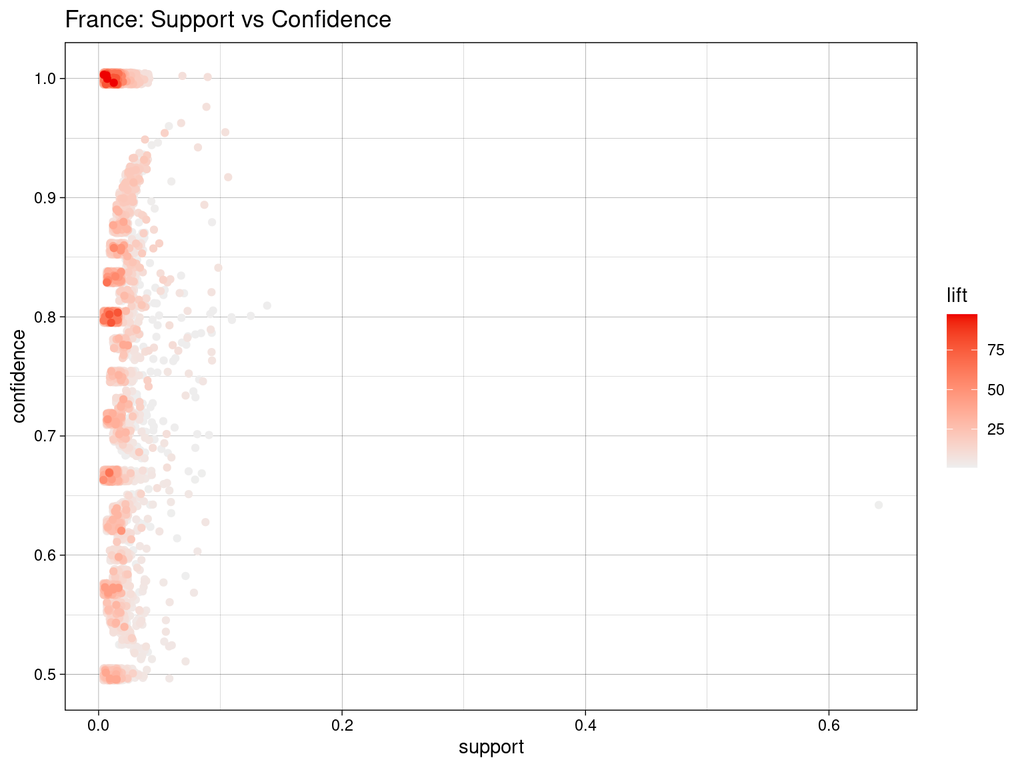

```r
plot(rules_fra,
     measure = c("support","confidence"),
     shading = "lift",
     main="France: Support vs Confidence")
```

## SCATTER PLOT - OTHER REGIONS

```
## To reduce overplotting, jitter is added! Use jitter = 0 to prevent jitter.
```

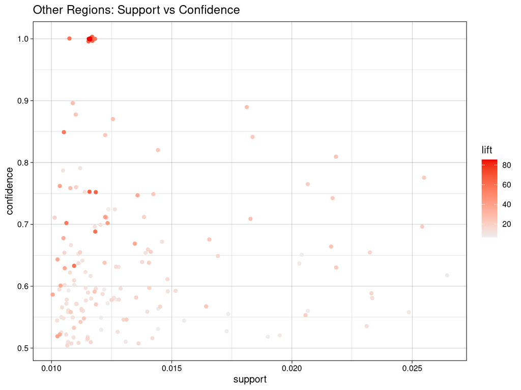

```r
plot(rules_other,
     measure = c("support","confidence"),
     shading = "lift",
     main="Other Regions: Support vs Confidence")
```

## GRAPH OF STRONGEST RULES - FRANCE

[output not shown]

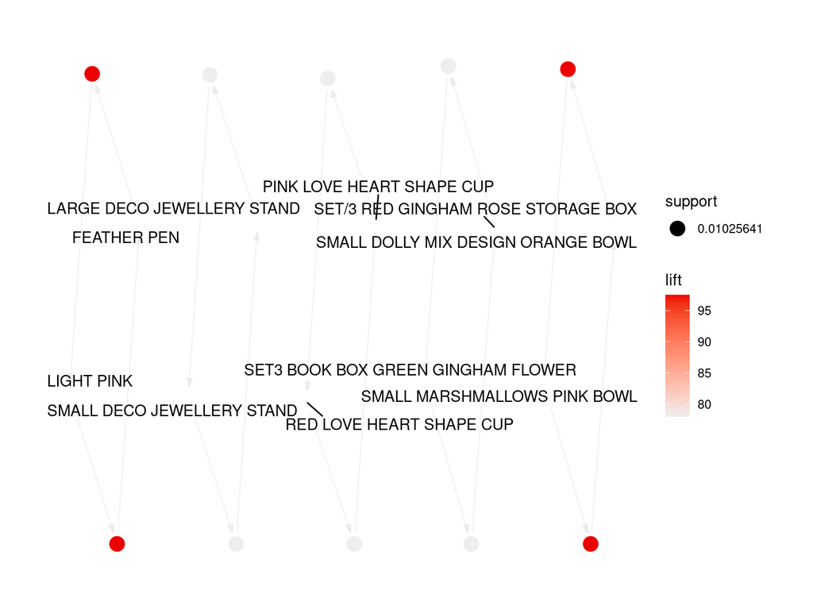

```r
top_fra <- head(sort(rules_fra, by="lift"), 10)
plot(top_fra, method="graph", control=list(type="items"),
     main="France: Top 10 Strongest Rules")
```

## GRAPH OF STRONGEST RULES - OTHER REGIONS

[output not shown]

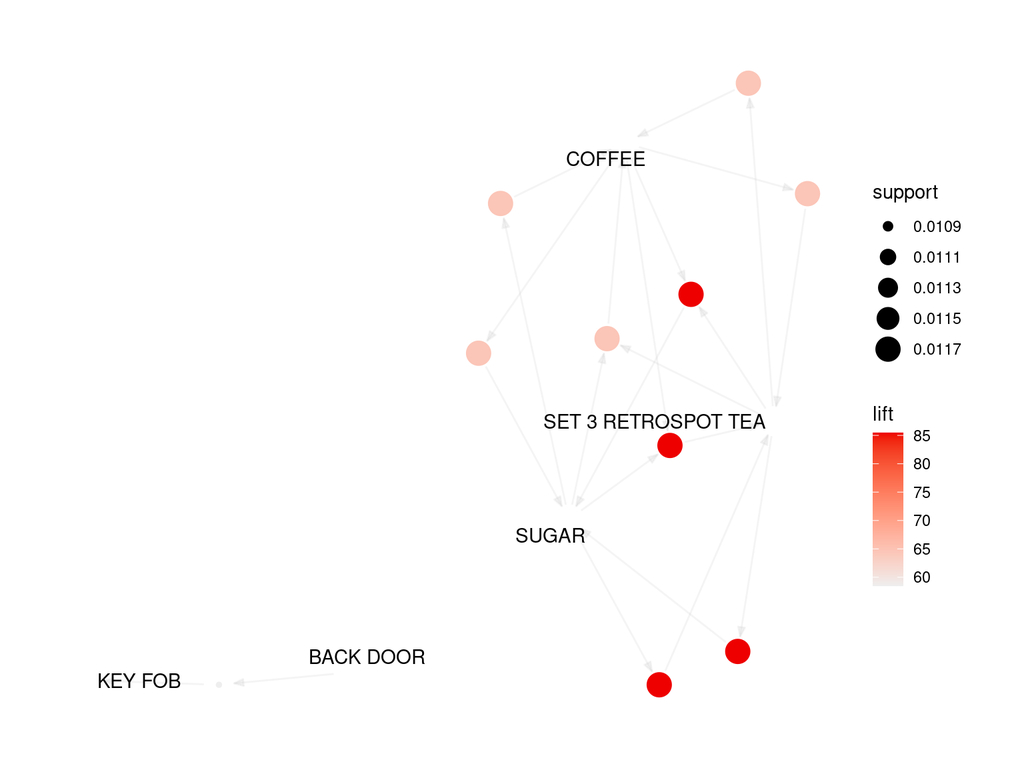

```r
top_other <- head(sort(rules_other, by="lift"), 10)
plot(top_other, method="graph", control=list(type="items"),
     main="Other Countries: Top 10 Strongest Rules")
```